# Juvenile Snowshoe Hares - Bonanza Creek

Eli Schulman

11/3/2021

*Introduction:* This report provides an exploration of Juvenile Snowshoe Hair data from the Bonanza Creek Experimental Forest (Long Term Ecological Research Site). The main areas of focus are trends in annual Hare trappings, as well weight differences between sexes and site. Additionally, special attention is given to weight comparisons between male and female Hares and an analysis of how weight corresponds to certain other Hare characteristics.

*Data and Analysis:* The data was taken via capture-recapture studies in Tanana Valley between 1999 and 2012. Hare densities were greatest in 1999, which is consistent with this reports analysis, and declined thereafter. The data was collected as part of the Environmental Data Initiative. All analyses in this report are done using RStudio.

### 1. Annual Juvenile Snowshoe Hare Trap Coounts

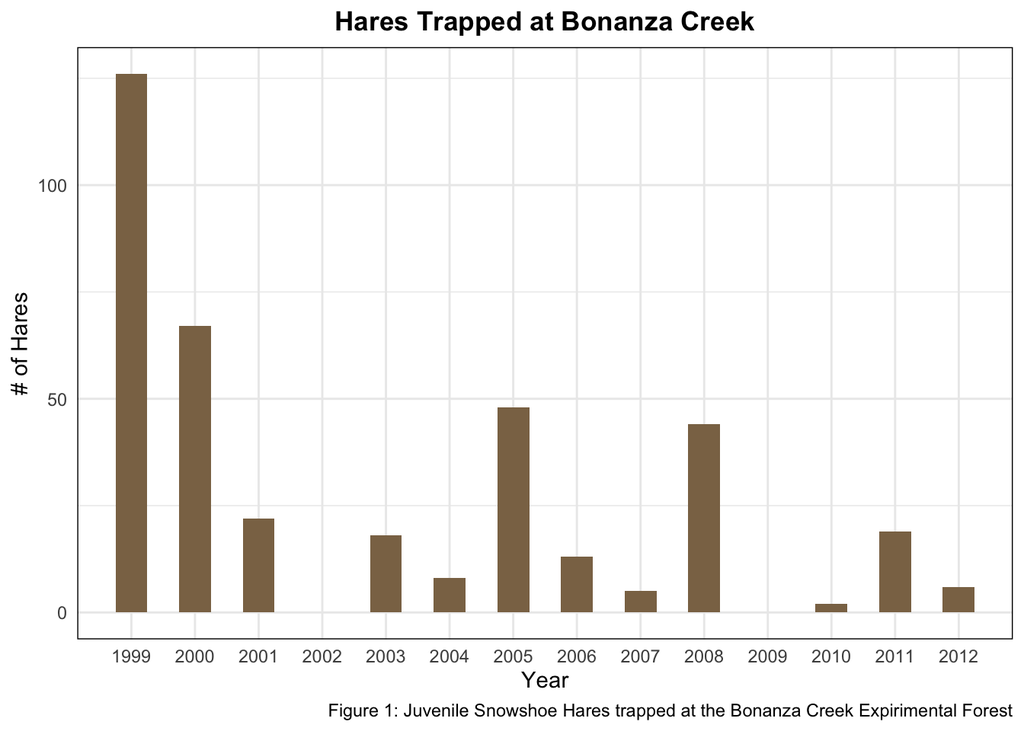

Trapped Snowshoes Takeaway: There is a observed decline in Juvenile Snowshoe Hares at Bonanza Creek between 1999 and 2012. However, there are also gaps in the data where no trapped hares were observed (2002, 2009). This indicates that sampling techniques may have lacked in those years, and more generally, could be waning over time. This would be consistent with the observed decline in hare trappings over the years, too. That being said, the average count of juvenile Hares in the study was 32 per year, with a max count of 126 in 1999. This might reflect a relatively high level of interest in the sampling at the onset of the project.

### 2. Juvenile Snowshoe Hare Weights by Sex and Grid

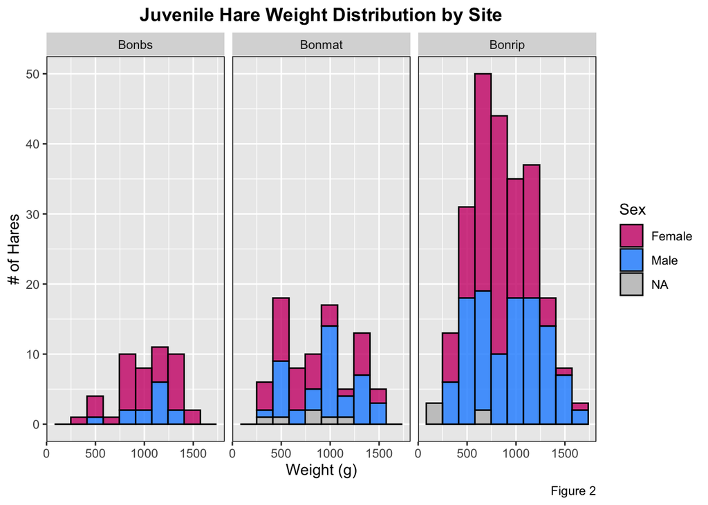

Fig-2: Mean Juvenile Snowshoe Hare weights for females at Bonbs, Bonmat, and Bonrip are 1022(g), 808(g), and 824(g), respectively. The mean weight for male hares are 1073(g), 950(g), and 929(g), respectively.

### 3. Juvenile Snowshoe Hare Weight Comparisons (Male vs Female)

Female vs Male Juvenile Snowshoe Hare Weights

| Sex | Mean (g) | Standard Deviation (g) | Sampel Size |
| --- | --- | --- | --- |
| Female | 855 | 292 | 200 |
| Male | 946 | 333 | 163 |
| NA | 615 | 358 | 15 |

#### Descriptive Statistics Analysis:

On average, male juvenile Snowshoe Hares have a higher weight than female juvenile Snowshoe hares (946 ± 333 and 855 ± 292, respectively; mean ± 1 standard deviation). The absolute difference in means of 91 (a 10.64% difference), is significant (Welchs two-sample t-test t(325.02) = -2.71, p.val = 0.007), though the effect size is small (Cohen’s d = -0.29).

### 4. Juvenile Hare Weight and Hind Foot Length Relationship

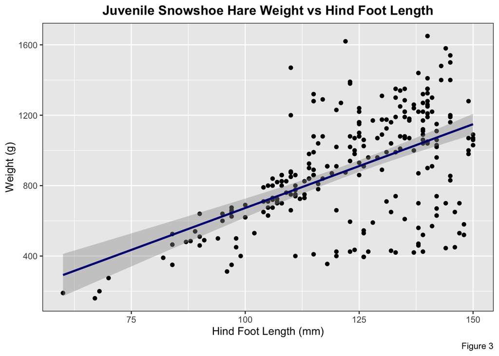

Fig-3: Relationship between Juvenile Snowshoe Hare weight (g) and hind foot length (mm). Linear model summary: $\beta$<sub>1</sub> = 9.52 g/mm, p<.001, R<sup>2</sup> = 0.299, Pearson’s r = 0.55.

### *Summary:*

Exploratory data of Juvenile Snowshoe Hares reveals the following:

- Hare trappings have decreased on average since the initialization of the Bonanza Creek monitoring program
- The Bonrip grid location has had more Hare observations than the other sites in the study (Bonbs and Bonmat)
- There is a significant difference in male and female weights amond hares (~91 g on average)
- Among Hares, there is a positive correlation between hind foot length and weight

### *Data Citation:*

Kielland, K., F.S. Chapin, R.W. Ruess, and Bonanza Creek LTER. 2017. Snowshoe hare physical data in Bonanza Creek Experimental Forest: 1999-Present ver 22. Environmental Data Initiative. https://doi.org/10.6073/pasta/03dce4856d79b91557d8e6ce2cbcdc14